# (PISA_2012 Data Visualization)

## by (Mostafa Massoud)

### Understand The Data

**PISA is a survey of students' skills and knowledge as they approach the end of compulsory education. It is not a conventional school test. Rather than examining how well students have learned the school curriculum, it looks at how well prepared they are for life beyond school.**

**Around 510,000 students in 65 economies took part in the PISA 2012 assessment of reading, mathematics and science representing about 28 million 15-year-olds globally. Of those economies, 44 took part in an assessment of creative problem solving and 18 in an assessment of financial literacy.**

**With the original data comes a second csv file which contain small describtion for the data columns**

# Contents:

- Preliminary Wrangling
- Creating Analysis DataFrame
- Data Wrangling
- Univariate Exploration
- Bivariate Exploration
- Multivariate Exploration

```python
# This Python 3 environment comes with many helpful analytics libraries installed
# It is defined by the kaggle/python Docker image: https://github.com/kaggle/docker-python
# For example, here's several helpful packages to load

import numpy as np # linear algebra
import pandas as pd # data processing, CSV file I/O (e.g. pd.read_csv)
import matplotlib.pyplot as plt
import seaborn as sns


# Input data files are available in the read-only "../input/" directory
# For example, running this (by clicking run or pressing Shift+Enter) will list all files under the input directory

import os
for dirname, _, filenames in os.walk('/kaggle/input'):
    for filename in filenames:
        print(os.path.join(dirname, filename))

# You can write up to 20GB to the current directory (/kaggle/working/) that gets preserved as output when you create a version using "Save & Run All"
# You can also write temporary files to /kaggle/temp/, but they won't be saved outside of the current session
```

```
/kaggle/input/pisa2012/pisadict2012.csv
/kaggle/input/pisa2012/pisa2012.csv/pisa2012.csv
```

Return to Contents

# Preliminary Wrangling

**In this section I will read the data set and decide the features I want to include in my visualization**

```python
%%time
#reading datasets and droping index column in the file
pisa = pd.read_csv('/kaggle/input/pisa2012/pisa2012.csv/pisa2012.csv',encoding='latin',low_memory=False).drop('Unnamed: 0',axis=1)
dict_pisa = pd.read_csv('/kaggle/input/pisa2012/pisadict2012.csv',encoding='latin',index_col=0).to_dict()['x']
```

```
CPU times: user 2min 14s, sys: 10 s, total: 2min 24s
Wall time: 2min 47s
```

```python
#data describtion
print(pisa.shape)
print(pisa.info())
pisa.head()
```

```
(485490, 635)
<class 'pandas.core.frame.DataFrame'>
RangeIndex: 485490 entries, 0 to 485489
Columns: 635 entries, CNT to VER_STU
dtypes: float64(250), int64(17), object(368)
memory usage: 2.3+ GB
None
```

|  | CNT | SUBNATIO | STRATUM | OECD | NC | SCHOOLID | STIDSTD | ST01Q01 | ST02Q01 | ST03Q01 | ... | W_FSTR75 | W_FSTR76 | W_FSTR77 | W_FSTR78 | W_FSTR79 | W_FSTR80 | WVARSTRR | VAR_UNIT | SENWGT_STU | VER_STU |
| --- | --- | --- | --- | --- | --- | --- | --- | --- | --- | --- | --- | --- | --- | --- | --- | --- | --- | --- | --- | --- | --- |
| 0 | Albania | 80000 | ALB0006 | Non-OECD | Albania | 1 | 1 | 10 | 1.0 | 2 | ... | 13.7954 | 13.9235 | 13.1249 | 13.1249 | 4.3389 | 13.0829 | 19 | 1 | 0.2098 | 22NOV13 |
| 1 | Albania | 80000 | ALB0006 | Non-OECD | Albania | 1 | 2 | 10 | 1.0 | 2 | ... | 13.7954 | 13.9235 | 13.1249 | 13.1249 | 4.3389 | 13.0829 | 19 | 1 | 0.2098 | 22NOV13 |
| 2 | Albania | 80000 | ALB0006 | Non-OECD | Albania | 1 | 3 | 9 | 1.0 | 9 | ... | 12.7307 | 12.7307 | 12.7307 | 12.7307 | 4.2436 | 12.7307 | 19 | 1 | 0.1999 | 22NOV13 |
| 3 | Albania | 80000 | ALB0006 | Non-OECD | Albania | 1 | 4 | 9 | 1.0 | 8 | ... | 12.7307 | 12.7307 | 12.7307 | 12.7307 | 4.2436 | 12.7307 | 19 | 1 | 0.1999 | 22NOV13 |
| 4 | Albania | 80000 | ALB0006 | Non-OECD | Albania | 1 | 5 | 9 | 1.0 | 10 | ... | 12.7307 | 12.7307 | 12.7307 | 12.7307 | 4.2436 | 12.7307 | 19 | 1 | 0.1999 | 22NOV13 |

5 rows × 635 columns

**As we can see the data is huge with ~500,000 intry and over 600 columns which are to much to handel. Inorder to make sense of some of the data insights we should choose some columns to foucs our analysis on**

**I will invistigate columns that is related to mathematics performace for students**

```python
#exploring catagorical columns
for col in pisa.select_dtypes(exclude=np.number).columns:
    print(col,dict_pisa[col])
```

```
CNT Country code 3-character
STRATUM Stratum ID 7-character (cnt + region ID + original stratum ID)
OECD OECD country
NC National Centre 6-digit Code
ST04Q01 Gender
ST05Q01 Attend <ISCED 0>
ST07Q01 Repeat - <ISCED 1>
ST07Q02 Repeat - <ISCED 2>
ST07Q03 Repeat - <ISCED 3>
ST08Q01 Truancy - Late for School
ST09Q01 Truancy - Skip whole school day
ST11Q01 At Home - Mother
ST11Q02 At Home - Father
ST11Q03 At Home - Brothers
ST11Q04 At Home - Sisters
ST11Q05 At Home - Grandparents
ST11Q06 At Home - Others
ST13Q01 Mother<Highest Schooling>
ST14Q01 Mother Qualifications - <ISCED level 6>
ST14Q02 Mother Qualifications - <ISCED level 5A>
ST14Q03 Mother Qualifications - <ISCED level 5B>
ST14Q04 Mother Qualifications - <ISCED level 4>
ST15Q01 Mother Current Job Status
ST17Q01 Father<Highest Schooling>
ST18Q01 Father Qualifications - <ISCED level 6>
ST18Q02 Father Qualifications - <ISCED level 5A>
ST18Q03 Father Qualifications - <ISCED level 5B>
ST18Q04 Father Qualifications - <ISCED level 4>
ST19Q01 Father Current Job Status
ST20Q01 Country of Birth International - Self
ST20Q02 Country of Birth International - Mother
ST20Q03 Country of Birth International - Father
ST25Q01 International Language at Home
ST26Q01 Possessions - desk
ST26Q02 Possessions - own room
ST26Q03 Possessions - study place
ST26Q04 Possessions - computer
ST26Q05 Possessions - software
ST26Q06 Possessions - Internet
ST26Q07 Possessions - literature
```

[output cut: 313 more lines]

```
COBN_M Country of Birth National Categories- Mother
COBN_S Country of Birth National Categories- Self
FISCED Educational level of father (ISCED)
HISCED Highest educational level of parents
IMMIG Immigration status
ISCEDD ISCED designation
ISCEDL ISCED level
ISCEDO ISCED orientation
LANGN Language at home (3-digit code)
MISCED Educational level of mother (ISCED)
OCOD1 ISCO-08 Occupation code - Mother
OCOD2 ISCO-08 Occupation code - Father
REPEAT Grade Repetition
TESTLANG Language of the test
VER_STU Date of the database creation
```

```python
#exploring Numeric columns
for col in pisa.select_dtypes(include=np.number).columns:
    if 'math' in dict_pisa[col].lower():
        print(col,dict_pisa[col])
```

```
ST69Q02 Min in <class period> - <Maths>
ST70Q02 No of <class period> p/wk - <Maths>
ANXMAT Mathematics Anxiety
CLSMAN Mathematics Teacher's Classroom Management
COGACT Cognitive Activation in Mathematics Lessons
EXAPPLM Experience with Applied Mathematics Tasks at School
EXPUREM Experience with Pure Mathematics Tasks at School
FAILMAT Attributions to Failure in Mathematics
FAMCON Familiarity with Mathematical Concepts
FAMCONC Familiarity with Mathematical Concepts (Signal Detection  Adjusted)
INSTMOT Instrumental Motivation for Mathematics
INTMAT Mathematics Interest
MATBEH Mathematics Behaviour
MATHEFF Mathematics Self-Efficacy
MATINTFC Mathematics Intentions
MATWKETH Mathematics Work Ethic
MMINS Learning time (minutes per week)- <Mathematics>
MTSUP Mathematics Teacher's Support
SCMAT Mathematics Self-Concept
SUBNORM Subjective Norms in Mathematics
USEMATH Use of ICT in Mathematic Lessons
ANCCLSMAN Mathematics Teacher's Classroom Management (Anchored)
ANCCOGACT Cognitive Activation in Mathematics Lessons (Anchored)
ANCINSTMOT Instrumental Motivation for Mathematics (Anchored)
ANCINTMAT Mathematics Interest (Anchored)
ANCMATWKETH Mathematics Work Ethic (Anchored)
ANCMTSUP Mathematics Teacher's Support (Anchored)
ANCSCMAT Mathematics Self-Concept (Anchored)
ANCSUBNORM Subjective Norms in Mathematics (Anchored)
PV1MATH Plausible value 1 in mathematics
PV2MATH Plausible value 2 in mathematics
PV3MATH Plausible value 3 in mathematics
PV4MATH Plausible value 4 in mathematics
PV5MATH Plausible value 5 in mathematics
PV1MACC Plausible value 1 in content subscale of math - Change and Relationships
PV2MACC Plausible value 2 in content subscale of math - Change and Relationships
PV3MACC Plausible value 3 in content subscale of math - Change and Relationships
PV4MACC Plausible value 4 in content subscale of math - Change and Relationships
PV5MACC Plausible value 5 in content subscale of math - Change and Relationships
PV1MACQ Plausible value 1 in content subscale of math - Quantity
```

[output cut: 14 more lines]

```
PV1MAPE Plausible value 1 in process subscale of math - Employ
PV2MAPE Plausible value 2 in process subscale of math - Employ
PV3MAPE Plausible value 3 in process subscale of math - Employ
PV4MAPE Plausible value 4 in process subscale of math - Employ
PV5MAPE Plausible value 5 in process subscale of math - Employ
PV1MAPF Plausible value 1 in process subscale of math - Formulate
PV2MAPF Plausible value 2 in process subscale of math - Formulate
PV3MAPF Plausible value 3 in process subscale of math - Formulate
PV4MAPF Plausible value 4 in process subscale of math - Formulate
PV5MAPF Plausible value 5 in process subscale of math - Formulate
PV1MAPI Plausible value 1 in process subscale of math - Interpret
PV2MAPI Plausible value 2 in process subscale of math - Interpret
PV3MAPI Plausible value 3 in process subscale of math - Interpret
PV4MAPI Plausible value 4 in process subscale of math - Interpret
PV5MAPI Plausible value 5 in process subscale of math - Interpret
```

**After looking in columns names I choosed 6 catagorical columns and 4 numeric values to do analysis on with respect to plausible values on mathsematics**

```python
#Choosen columns
cat_cols = ['CNT','ST08Q01','ST09Q01','ST13Q01','ST17Q01','ST29Q04']
num_cols = ['MTSUP','INTMAT','ST69Q02','ST70Q02']
plausible_values = ['PV1MATH','PV2MATH','PV3MATH','PV4MATH','PV5MATH']
```

*Befor we continue forward I think it's important to understand plausible values, as I won't invistigate plausible value individually. While noting that it's wrong to treat plausible values as scores for students, because it is a better population estimated values based on the scoring of students. But for the simplicity to my visualization I shall invistigate the data with the mean of the plausible values of mathematics, since my goal is not the statistical meaning of the data but visualization of the data.*

*More info about plausible values and about the data generally can be found in the following links:

[PISA-2012](https://www.oecd.org/pisa/pisaproducts/PISA-2012-technical-report-final.pdf) **You can see 'Analysis of data with plausible values' in chapter9 for more explanation about plausible values*

[Plausible Values](https://www.oecd-ilibrary.org/docserver/9789264056275-7-en.pdf?expires=1613635190&id=id&accname=guest&checksum=28A261A3232AB1FE8D31D82514CAA726)

Return to Contents

# Creating Analysis DataFrame

```python
%%time
#Gathering columns of intrest in analysis dataframe to start our invistigation
analysis_df = pisa[cat_cols+num_cols].copy()
#creating plausible value mean column
analysis_df['PVMATH_mean'] = pisa[plausible_values].apply(lambda x:x.mean(),axis=1)
```

```
CPU times: user 28.9 s, sys: 5.39 s, total: 34.3 s
Wall time: 27.9 s
```

```python
print(f'DataFrame shape = {analysis_df.shape}')
print(analysis_df.info())
analysis_df.head()
```

```
DataFrame shape = (485490, 11)
<class 'pandas.core.frame.DataFrame'>
RangeIndex: 485490 entries, 0 to 485489
Data columns (total 11 columns):
 #   Column       Non-Null Count   Dtype
---  ------       --------------   -----
 0   CNT          485490 non-null  object
 1   ST08Q01      479143 non-null  object
 2   ST09Q01      479131 non-null  object
 3   ST13Q01      457979 non-null  object
 4   ST17Q01      443261 non-null  object
 5   ST29Q04      314737 non-null  object
 6   MTSUP        313599 non-null  float64
 7   INTMAT       316708 non-null  float64
 8   ST69Q02      298601 non-null  float64
 9   ST70Q02      298339 non-null  float64
 10  PVMATH_mean  485490 non-null  float64
dtypes: float64(5), object(6)
memory usage: 40.7+ MB
None
```

|  | CNT | ST08Q01 | ST09Q01 | ST13Q01 | ST17Q01 | ST29Q04 | MTSUP | INTMAT | ST69Q02 | ST70Q02 | PVMATH_mean |
| --- | --- | --- | --- | --- | --- | --- | --- | --- | --- | --- | --- |
| 0 | Albania | None | None | <ISCED level 3A> | <ISCED level 3A> | Agree | -0.9508 | 0.91 | NaN | NaN | 366.18634 |
| 1 | Albania | One or two times | None | <ISCED level 3A> | <ISCED level 3A> | Disagree | NaN | 0.00 | 45.0 | 6.0 | 470.56396 |
| 2 | Albania | None | None | <ISCED level 3B, 3C> | <ISCED level 3A> | Agree | NaN | 1.23 | NaN | 4.0 | 505.53824 |
| 3 | Albania | None | None | <ISCED level 3B, 3C> | <ISCED level 3A> | NaN | 1.6748 | NaN | 45.0 | 3.0 | 449.45476 |
| 4 | Albania | One or two times | None | She did not complete <ISCED level 1> | <ISCED level 3B, 3C> | Disagree | 0.6709 | 0.30 | NaN | NaN | 385.50398 |

```python
#Taking a look on each column unique values
for col in analysis_df.select_dtypes(object).columns:
    unique = analysis_df[col].unique()
    print('-'*10,col,dict_pisa[col],'-'*10)
    print(f'Has {len(unique)} Unique Values Some of Which Are:')
    print(unique[:10])
```

```
---------- CNT Country code 3-character ----------
Has 68 Unique Values Some of Which Are:
['Albania' 'United Arab Emirates' 'Argentina' 'Australia' 'Austria'
 'Belgium' 'Bulgaria' 'Brazil' 'Canada' 'Switzerland']
---------- ST08Q01 Truancy - Late for School ----------
Has 5 Unique Values Some of Which Are:
['None  ' 'One or two times  ' 'Three or four times  ' nan
 'Five or more times  ']
---------- ST09Q01 Truancy - Skip whole school day ----------
Has 5 Unique Values Some of Which Are:
['None  ' nan 'One or two times  ' 'Three or four times  '
 'Five or more times  ']
---------- ST13Q01 Mother<Highest Schooling> ----------
Has 6 Unique Values Some of Which Are:
['<ISCED level 3A> ' '<ISCED level 3B, 3C> '
 'She did not complete <ISCED level 1> ' '<ISCED level 2> '
 '<ISCED level 1> ' nan]
---------- ST17Q01 Father<Highest Schooling> ----------
Has 6 Unique Values Some of Which Are:
['<ISCED level 3A> ' '<ISCED level 3B, 3C> ' '<ISCED level 2> '
 'He did not complete <ISCED level 1> ' nan '<ISCED level 1> ']
---------- ST29Q04 Math Interest - Enjoy Maths ----------
Has 5 Unique Values Some of Which Are:
['Agree' 'Disagree' nan 'Strongly agree' 'Strongly disagree']
```

```python
#Statistical describtion of our data
analysis_df.describe()
```

|  | MTSUP | INTMAT | ST69Q02 | ST70Q02 | PVMATH_mean |
| --- | --- | --- | --- | --- | --- |
| count | 313599.000000 | 316708.000000 | 298601.000000 | 298339.000000 | 485490.000000 |
| mean | 0.177720 | 0.212424 | 52.911273 | 4.350246 | 469.651234 |
| std | 1.011025 | 1.004716 | 17.007616 | 1.652565 | 100.786610 |
| min | -2.864500 | -1.780000 | 15.000000 | 0.000000 | 54.767080 |
| 25% | -0.657700 | -0.340000 | 45.000000 | 3.000000 | 396.019620 |
| 50% | 0.248600 | 0.300000 | 50.000000 | 4.000000 | 465.734520 |
| 75% | 1.116900 | 0.910000 | 55.000000 | 5.000000 | 540.123060 |
| max | 1.843300 | 2.290000 | 180.000000 | 40.000000 | 903.107960 |

```python
#Looking in correleation between columns
analysis_df.corr()
```

|  | MTSUP | INTMAT | ST69Q02 | ST70Q02 | PVMATH_mean |
| --- | --- | --- | --- | --- | --- |
| MTSUP | 1.000000 | 0.340001 | 0.012340 | 0.072879 | -0.061314 |
| INTMAT | 0.340001 | 1.000000 | 0.012113 | 0.110093 | 0.008515 |
| ST69Q02 | 0.012340 | 0.012113 | 1.000000 | -0.194646 | -0.060485 |
| ST70Q02 | 0.072879 | 0.110093 | -0.194646 | 1.000000 | 0.154489 |
| PVMATH_mean | -0.061314 | 0.008515 | -0.060485 | 0.154489 | 1.000000 |

```python
#Cecking duplicated values
analysis_df.duplicated().sum()
```

```
120
```

```python
#Checking null values
analysis_df.isnull().any()
```

```
CNT            False
ST08Q01         True
ST09Q01         True
ST13Q01         True
ST17Q01         True
ST29Q04         True
MTSUP           True
INTMAT          True
ST69Q02         True
ST70Q02         True
PVMATH_mean    False
dtype: bool
```

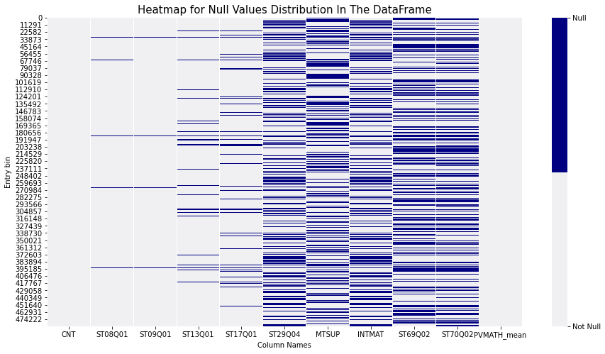

```python
#plotting heat map of null values
plt.figure(figsize=(15,8))
#plot
ax=sns.heatmap(analysis_df.isnull(),cmap=sns.color_palette('light:navy',2));
#Customizing colorbar
cbar = ax.collections[0].colorbar
cbar.set_ticks([0,1])
cbar.set_ticklabels(['Not Null','Null'])
#Customizing figure titles
plt.title('Heatmap for Null Values Distribution In The DataFrame',size=15);
plt.ylabel('Entry bin');
plt.xlabel('Column Names');
```

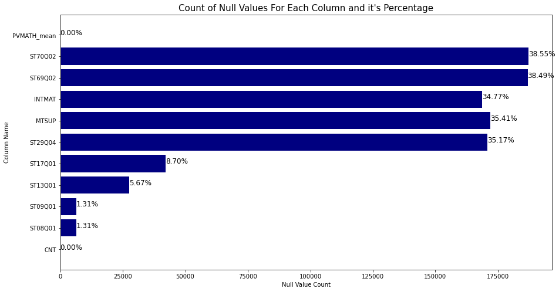

```python
##plotting bar graph of null values count.
plt.figure(figsize=(15,8))
#plotting Data
x = analysis_df.isnull().sum()
y = x.index
#plot
plt.barh(y=y,width=x,color=sns.color_palette('light:navy',2)[1]);
#Creating Percentage values and plotting on bar graph
pct_null = ['{:.2f}%'.format(x*100) for x in analysis_df.isnull().sum()/analysis_df.shape[0]]
for i in range(len(y)):
    pct_str = pct_null[i]
    pos = x[i]
    plt.text(pos,i,pct_str,size=12)
#Customizing figure titles
plt.title('Count of Null Values For Each Column and it\'s Percentage',size=15);
plt.ylabel('Column Name');
plt.xlabel('Null Value Count');
```

**Looking primarily on the data we found that it suffers from null values with each row contain atleast one null value which will complicate dealing with null values a bit, and nearly half of our columns having null values above 35% but not exceeding 38.6%. and we have only 120 dublicated rows**

Return to Contents

# Data Wrangling

#### After exploring our data in the previous step we can make some small modification on our data so we can start with exploring it with visualization.

###### First: Dropping duplicates

```python
#droping duplicates
analysis_df.drop_duplicates(inplace=True)
```

###### Second: Dealing with null values

> Since all rows contain at least one null value so I can't just delete null values but with more than 75% of rows contain only 2 null values I decided to remove rows contain more than 2 null values and continue analysis with the rest data

```python
%%time
#Exploring the number null values in every row
null = analysis_df.apply(lambda x:x.isnull().sum(), axis=1)
#choosing rows that has at most 2 null values
analysis_df = analysis_df[null<=2].copy()
analysis_df.shape
```

```
CPU times: user 1min 18s, sys: 1.31 s, total: 1min 19s
Wall time: 1min 17s
```

```
(415647, 11)
```

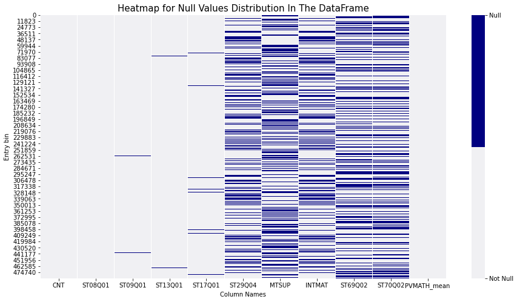

```python
#plotting heat map of null values
plt.figure(figsize=(15,8))
#plot
ax=sns.heatmap(analysis_df.isnull(),cmap=sns.color_palette('light:navy',2));
#Customizing colorbar
cbar = ax.collections[0].colorbar
cbar.set_ticks([0,1])
cbar.set_ticklabels(['Not Null','Null'])
#Customizing figure titles
plt.title('Heatmap for Null Values Distribution In The DataFrame',size=15);
plt.ylabel('Entry bin');
plt.xlabel('Column Names');
```

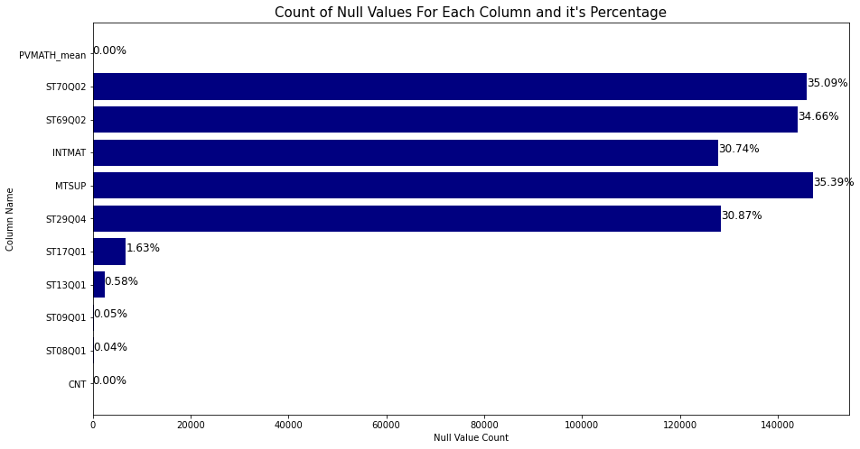

```python
##plotting bar graph of null values count.
plt.figure(figsize=(15,8))
#plotting Data
x = analysis_df.isnull().sum()
y = x.index
#plot
plt.barh(y=y,width=x,color=sns.color_palette('light:navy',2)[1]);
#Creating Percentage values and plotting on bar graph
pct_null = ['{:.2f}%'.format(x*100) for x in analysis_df.isnull().sum()/analysis_df.shape[0]]
for i in range(len(y)):
    pct_str = pct_null[i]
    pos = x[i]
    plt.text(pos,i,pct_str,size=12)
#Customizing figure titles
plt.title('Count of Null Values For Each Column and it\'s Percentage',size=15);
plt.ylabel('Column Name');
plt.xlabel('Null Value Count');
```

```python
#Changing columns name to more understandable names
dict_cols = {'CNT':'country',
            'ST08Q01':'late',
            'ST09Q01':'skip_day',
            'ST13Q01':'mother_edu',
            'ST17Q01':'father_edu',
            'ST29Q04':'enjoy_math',
            'MTSUP':'teacher_sup',
            'INTMAT':'math_interest',
            'ST69Q02':'min_class_period',
            'ST70Q02':'no_class_period',
            'PVMATH_mean':'pvmath_mean',}

cat_cols = [dict_cols[x] for x in cat_cols]
temp = analysis_df.columns
analysis_df.columns = [dict_cols[x] for x in temp]
```

###### Fourth: Changing columns values to more easily interpreted names

```python
#Changing the values in education columns according to https://ec.europa.eu/eurostat/cache/metadata/Annexes/educ_uoe_h_esms_an2.htm
dict_values = {'<ISCED level 3A> ':'lvl 3A',
           '<ISCED level 3B, 3C> ':'lvl (3B,3C)',
           'She did not complete <ISCED level 1> ':'lvl 0',
           'He did not complete <ISCED level 1> ':'lvl 0',
           '<ISCED level 2> ':'lvl 2',
           '<ISCED level 1> ':'lvl 1',
            'Five or more times  ':'5 or more',
             'Three or four times  ':'3-4 Times',
             'One or two times  ':'1-2 Times',
             'None  ':'Never',
            np.nan:np.nan}

analysis_df.replace(dict_values,inplace=True)
```

```python
#Ordering categorical types columns
ordinal_var_dict = {'late': ['5 or more', '3-4 Times', '1-2 Times','Never'],
                    'skip_day': ['5 or more', '3-4 Times', '1-2 Times', 'Never'],
                    'father_edu': ['lvl 0', 'lvl 1', 'lvl 2', 'lvl 3A','lvl (3B,3C)'],
                    'mother_edu': ['lvl 0', 'lvl 1', 'lvl 2', 'lvl 3A', 'lvl (3B,3C)'],
                    'enjoy_math': ['Strongly disagree', 'Disagree', 'Agree', 'Strongly agree']}

for var in ordinal_var_dict:
    ordered_var = pd.api.types.CategoricalDtype(ordered = True,
                                                categories = ordinal_var_dict[var])
    analysis_df[var] = analysis_df[var].astype(ordered_var)
```

Return to Contents

# Univariate Exploration

> In this section I will try to take a look for each column in the data.

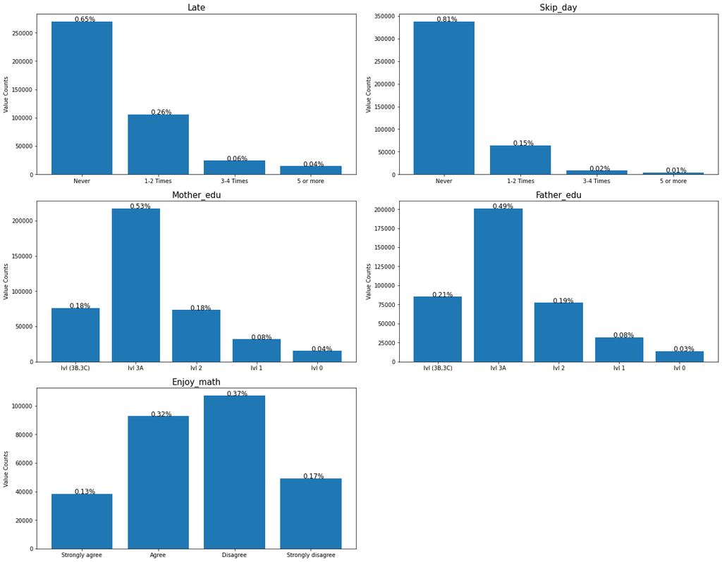

```python
#Bar chart catagorical columns except to country
cat_cols = analysis_df.select_dtypes(exclude=np.number).columns[1:] #catagorical columns
fig,axes = plt.subplots(3,2,figsize=(18,14),constrained_layout=True)
axes = axes.ravel()
axes[-1].remove() #removing last empty axis
for i in range(len(cat_cols)):
    col = cat_cols[i]
    ax = axes[i]
    temp = analysis_df[[col]].dropna() #dropping null values so the percentage will be accurate to all valid values
    #gathering data and plotting
    height = temp[col].value_counts(sort=False)
    x = height.index
    ax.bar(x,height)
    ax.invert_xaxis()
    #finishing figures label
    ax.set_title(col.capitalize(),size=15)
    ax.set_ylabel('Value Counts')
    #written percentage for each column on top of it
    pct = height/temp.shape[0]
    pct_str = ['{:.2f}%'.format(x) for x in pct]
    for i in range(len(x)):
        ax.text(i+0.1,height[i],pct_str[i],size=12)
```

**We can see the distribution of values for each column here. we can see that 54% of our students don't enjoy math, and most of parent's with higher education over ISCED level 3, also they less likely to miss a school day than going late to shcool**

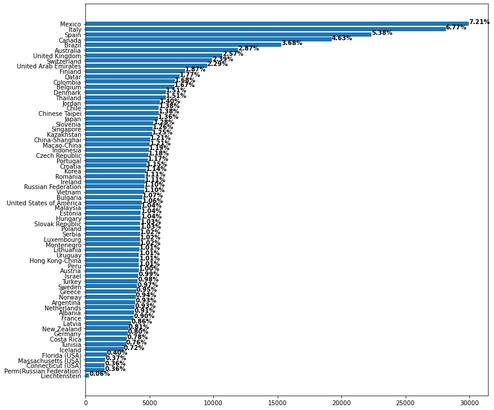

```python
#country bar graph
plt.figure(figsize=(12,12))
height = analysis_df['country'].value_counts()
x = height.index
plt.barh(x,height)
plt.gca().invert_yaxis()

pct = height/analysis_df.shape[0]
for i in range(len(x)):
    plt.text(height[i],i,'{:.2f}%'.format(pct[i]*100),fontweight='bold')
```

**From 68 countries participated in the study Mexico is the most frequent country.**

**Now let's take a look at the column of interest which is pvmath_mean**

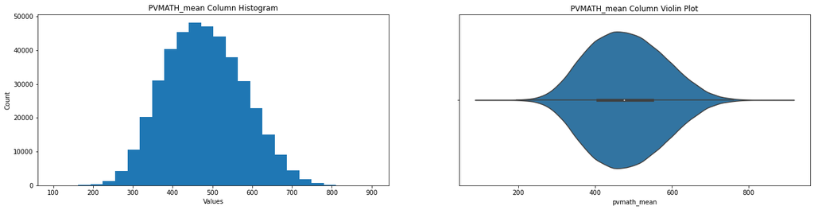

```python
# PVMATH_mean column investigation
plt.figure(figsize=(22,5))
plt.subplot(121)
bins = np.histogram_bin_edges(analysis_df['pvmath_mean'],bins='doane')
plt.hist(x='pvmath_mean', data= analysis_df,bins=bins)
plt.title('PVMATH_mean Column Histogram')
plt.ylabel('Count')
plt.xlabel('Values')

plt.subplot(122)
sns.violinplot(x='pvmath_mean', data=analysis_df);
plt.title('PVMATH_mean Column Violin Plot');
```

*We can see here that the values in pvmath_mean column is normally distributed, looking in the violin plot we can see some outliers represented with the black line extended both ways.*

*Now let's discover the numeric columns*

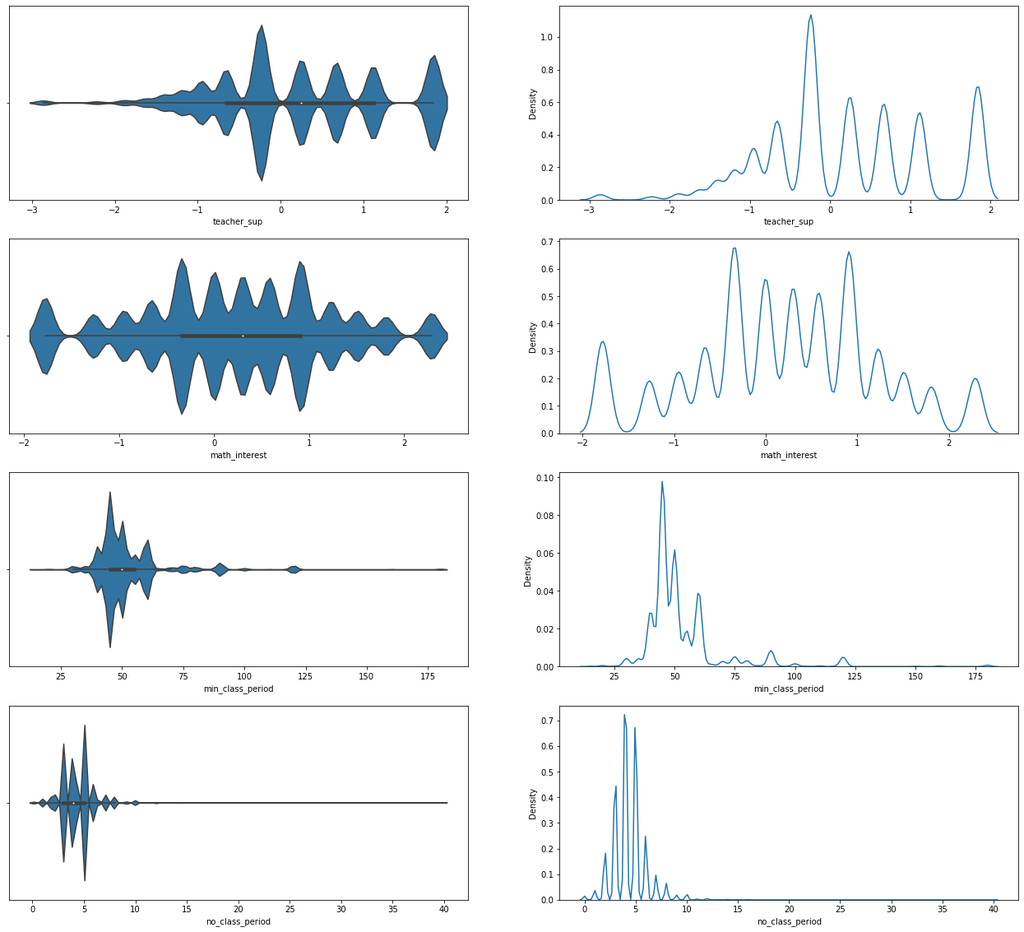

```python
#Plotting violin plots and kde plots
fig,axes = plt.subplots(4,2,figsize=(22,20))
num_cols = analysis_df.select_dtypes(np.number).columns[:-1]
for i in range(len(num_cols)):
    col = num_cols[i]
    ax1 = axes[i][0]
    ax2 = axes[i][1]
    #Violin plot
    sns.violinplot(x=col, data=analysis_df,ax=ax1)
    #Kdep lot
    sns.kdeplot(x=col, data=analysis_df, ax=ax2)
```

**Both min_class_period and no_class_period columns suffers greatly from outliers, while math_interest and teacher_sup doesn't have outliers with values ranges between -3 to 3 approximately.**

Return to Contents

# Bivariate Exploration

> In this section, investigate relationships between pairs of variables in your data. Make sure the variables that you cover here have been introduced in some fashion in the previous section (univariate exploration).

```python
scatter_matrix = analysis_df.select_dtypes(np.number)
scatter_matrix.shape
```

```
(415647, 5)
```

[output not shown]

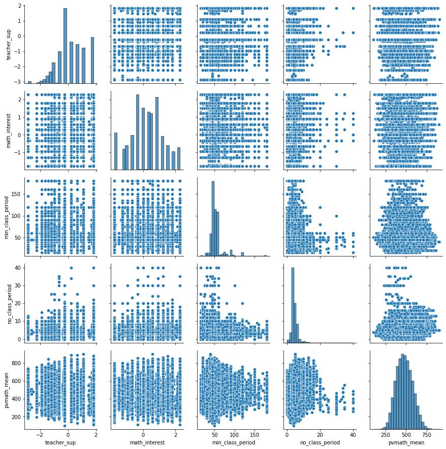

```python
%%time
g = sns.PairGrid(scatter_matrix,diag_sharey=False)
g.map_offdiag(sns.scatterplot)
g.map_diag(sns.histplot,bins='doane')
```

The Scatterplot between columns doesn't show much of relation except for no_class_period with pvmath_mean where the increasing of no of class period didn't mean increasing in pvmath value. Also the min of class period may have a inverse relation with no of class period.

```python
%%time
def higher_edu(row):
    '''
    Returns the heighest education level for both parent

    '''
    if row['father_edu'] is np.nan or row['mother_edu'] is np.nan:
        return np.nan
    edu_order = {'lvl 0':1, 'lvl 1':1, 'lvl 2':2, 'lvl 3A':3,'lvl (3B,3C)':4}
    father_education = row['father_edu']
    mother_education = row['mother_edu']

    if mother_education == father_education:
        return mother_education
    elif edu_order[father_education] > edu_order[mother_education]:
        return father_education
    else:
        return mother_education

analysis_df['higher_edu'] = analysis_df.apply(lambda x : higher_edu(x),axis=1)

analysis_df['higher_edu'] = analysis_df['higher_edu'].astype(pd.api.types.CategoricalDtype(ordered = True,
                                                categories = ['lvl 0', 'lvl 1', 'lvl 2', 'lvl 3A', 'lvl (3B,3C)']))

#Creating edu_df where there is no null values in columns of interest : [mother_edu,father_edu]
edu_df = analysis_df[~((analysis_df['father_edu'].isnull()) | (analysis_df['mother_edu'].isnull()))].copy()
edu_df.shape
```

```
CPU times: user 11.6 s, sys: 46.2 ms, total: 11.6 s
Wall time: 11.6 s
```

```
(406460, 12)
```

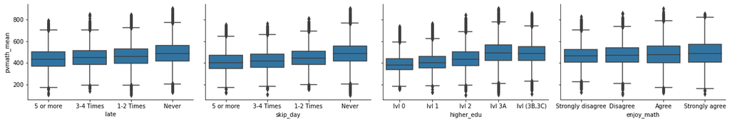

```python
plt.figure(figsize = [10, 10])
g = sns.PairGrid(data = analysis_df, y_vars = 'pvmath_mean', x_vars = ['late','skip_day','higher_edu','enjoy_math',],
                height = 3, aspect = 1.5);
g.map(sns.boxplot,color = sns.color_palette()[0]);
```

The mean for PVMATH values changes from each level of each catagorical columns we can see that the mean differe greatly from parent education level,Also there is difference of the PVMATH values mean between skip_day and late, and there is no big changes with different math enojoyment levels.

```python
def cat_facet_distibution(col,dataframe,ylim):
    '''
    Plotting for each different value in catagorical column boxplot and Histogram plot for pvmath_mean column
    '''
    values = {
        'mother_edu': [['lvl 0', 'lvl 1', 'lvl 2', 'lvl 3A', 'lvl (3B,3C)'],'Education Level for Parents'],
        'father_edu': [['lvl 0', 'lvl 1', 'lvl 2', 'lvl 3A', 'lvl (3B,3C)'],'Education Level for Parents'],
        'higher_edu': [['lvl 0', 'lvl 1', 'lvl 2', 'lvl 3A', 'lvl (3B,3C)'],'Education Level for Parents'],
        'enjoy_math': [['Strongly disagree', 'Disagree', 'Agree', 'Strongly agree'],'Maths Enjoyment'],
        'late':       [['5 or more', '3-4 Times', '1-2 Times','Never'],'Times Being Late to School'],
        'skip_day':   [['5 or more', '3-4 Times', '1-2 Times', 'Never'],'Times School Day Skipping']
             }

    column_values = values[col][0]
    #plotting ditribution of pvmath_mean with education level
    fig,axes = plt.subplots(2,len(column_values),figsize=(18,8),constrained_layout=True)
    fig.suptitle(f'Distribution of PVMATH Values with Different {values[col][1]}',size=15)


    for i in range(len(column_values)):
        #Getting plotting data and axes
        lvl = column_values[i]
        df = dataframe[dataframe[col]==lvl]
        ax1 = axes[0][i]
        ax2 = axes[1][i]
        #Boxplot
        sns.boxplot(x='pvmath_mean',data=df,ax=ax1)
        ax1.set_title(f'{lvl} PVMATH Values Boxplt \nWith Mean = {round(df["pvmath_mean"].mean(),2)}')
        ax1.set_xlabel('')
        #Histogram
        sns.histplot(x='pvmath_mean',data=df,ax=ax2)
        ax2.set_title(f'{lvl} PVMATH Values Histogram')
        ax2.set_ylim([0,ylim])
        ax2.set_xlabel('')
```

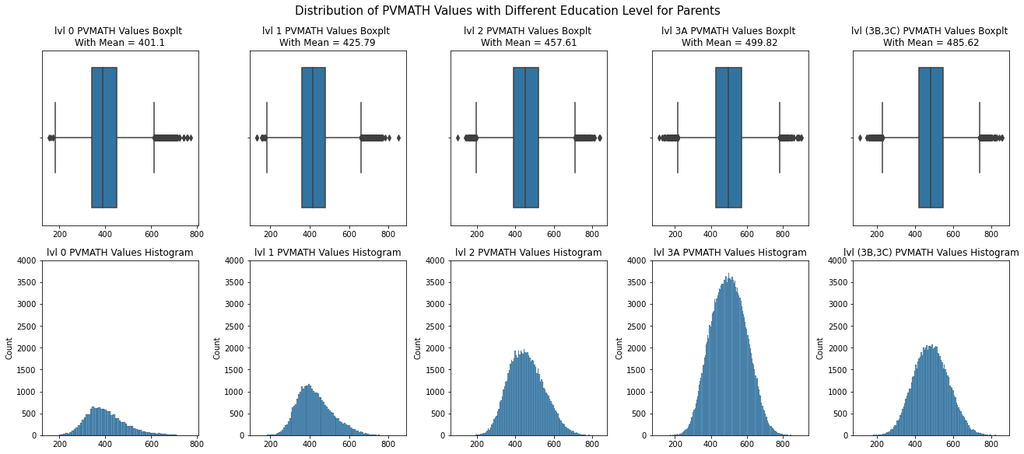

```python
cat_facet_distibution('father_edu',edu_df,4000)
```

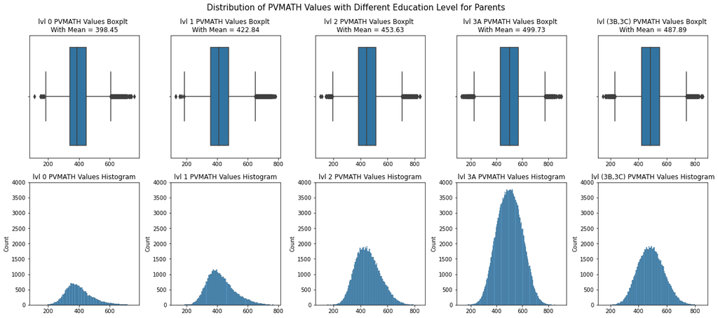

```python
cat_facet_distibution('mother_edu',edu_df,4000)
```

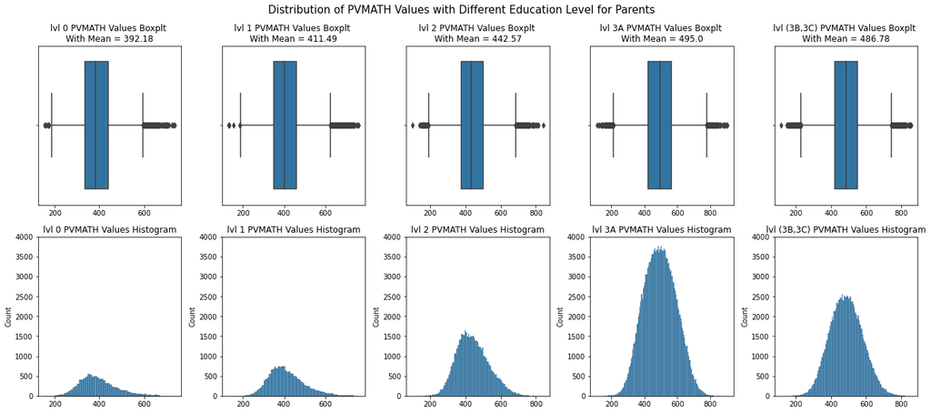

```python
cat_facet_distibution('higher_edu',edu_df,4000)
```

The above three figures the distributions look the same with lower education level have more right skewed distribution to lower PVMATH values and hence lower mean value as we saw from boxplot before. and histogram take more normally distributed look with education level 3.

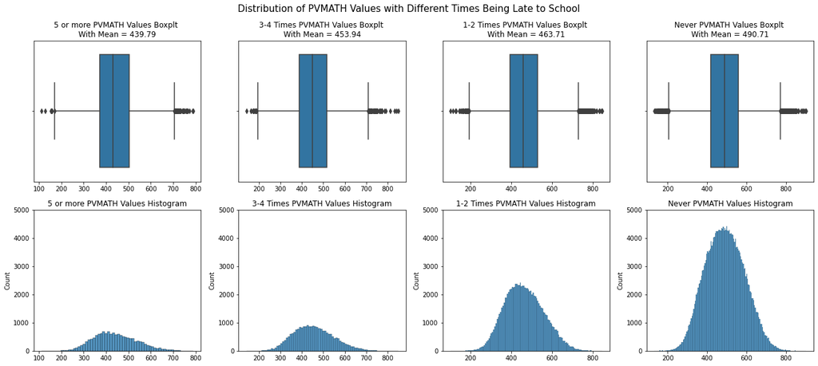

```python
cat_facet_distibution('late',edu_df,5000)
```

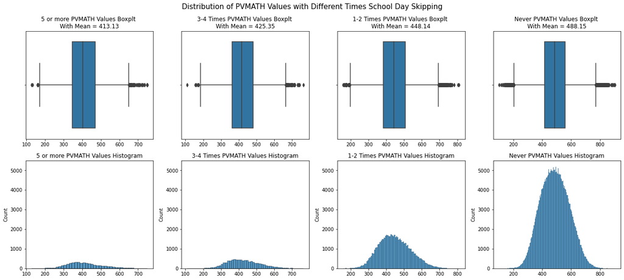

```python
cat_facet_distibution('skip_day',edu_df,5500)
```

The distribution from late and skip_day columns looks also similar with slightly right skewed distribution for being more late or skipping more days with lower PVMATH mean value, while it gets more normally distributed with 'never' value in both columns.

Return to Contents

## Multivariate Exploration

> Create plots of three or more variables to investigate your data even further. Make sure that your investigations are justified, and follow from your work in the previous sections.

```python
class_period = analysis_df[~((analysis_df['no_class_period'].isnull())|(analysis_df['higher_edu'].isnull()))].copy()
class_period.shape
```

```
(260858, 12)
```

```python
class_period.describe()
```

|  | teacher_sup | math_interest | min_class_period | no_class_period | pvmath_mean |
| --- | --- | --- | --- | --- | --- |
| count | 127718.000000 | 133098.000000 | 254313.000000 | 260858.000000 | 260858.000000 |
| mean | 0.121583 | 0.226804 | 52.910229 | 4.369140 | 482.636741 |
| std | 1.016629 | 0.966396 | 16.800677 | 1.633879 | 97.743456 |
| min | -2.864500 | -1.780000 | 15.000000 | 0.000000 | 101.347560 |
| 25% | -0.657700 | -0.340000 | 45.000000 | 3.000000 | 410.975220 |
| 50% | -0.239500 | 0.300000 | 50.000000 | 4.000000 | 479.365940 |
| 75% | 0.670900 | 0.910000 | 55.000000 | 5.000000 | 551.183980 |
| max | 1.843300 | 2.290000 | 180.000000 | 40.000000 | 903.107960 |

```python
def remove_outlier(df,col):
    '''
    Return DataFrame "df" with now outlier in column "col"
    '''
    Q1 = class_period[col].quantile(0.25)
    Q3 = class_period[col].quantile(0.75)
    IQR = Q3 - Q1
    return df[~((df[col] < (Q1 - 1.5 * IQR)) |(df[col] > (Q3 + 1.5 * IQR)))].copy()

def multi_regplot_facet(df,cat_col,num_col,height=4,aspect=0.8):
    '''
    Creating FacetGrid for catagorical column with numerical column from DataFrame
    And mapping regplot to the FacetGrid.
    '''
    facetgrid = sns.FacetGrid(data=df, col=cat_col, height=height, aspect=aspect)
    facetgrid.map(sns.regplot,num_col,'pvmath_mean',x_jitter=0.07,scatter_kws={'alpha':1/10})

def multi_scatter_facet(df,cat_col,num_col,height=4,aspect=0.8):
    '''
    Creating FacetGrid for catagorical column with numerical column from DataFrame
    And mapping scatterplot to the FacetGrid.
    '''
    facetgrid = sns.FacetGrid(data=df, col=cat_col, height=height, aspect=aspect)
    facetgrid.map(sns.scatterplot,num_col,'pvmath_mean')
```

# No_class_period vs Higher_education vs PVMATH

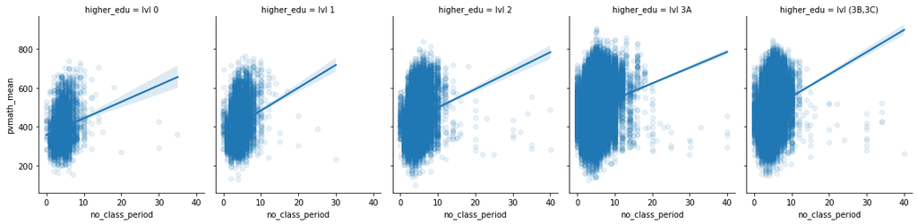

```python
multi_regplot_facet(class_period,'higher_edu','no_class_period',height=4,aspect=0.8)
```

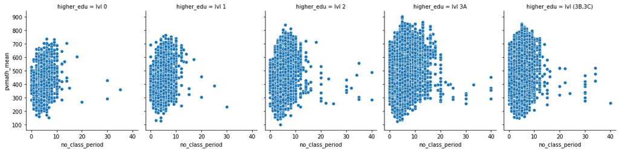

```python
multi_scatter_facet(class_period,'higher_edu','no_class_period',height=4,aspect=0.8)
```

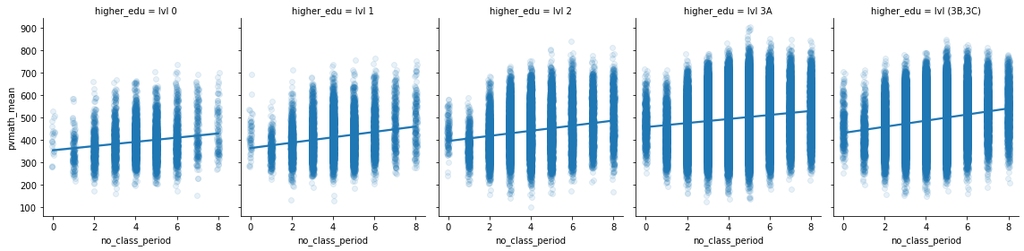

```python
no_outliers = remove_outlier(class_period,'no_class_period')
multi_regplot_facet(no_outliers,'higher_edu','no_class_period',height=4,aspect=0.8)
```

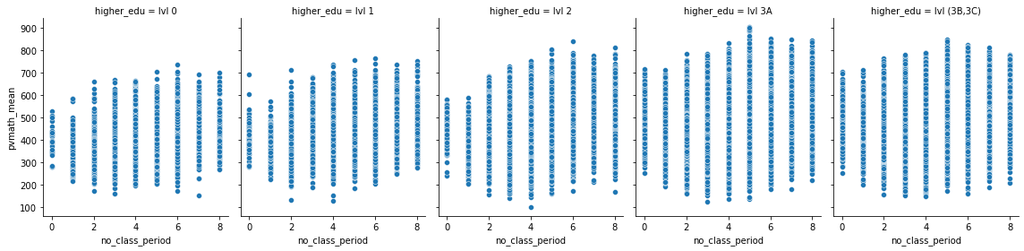

```python
multi_scatter_facet(no_outliers,'higher_edu','no_class_period',height=4,aspect=0.8)
```

# Teacher_sup vs Higher_education vs PVMATH

```python
teacher_sup = analysis_df[~((analysis_df['teacher_sup'].isnull())|(analysis_df['higher_edu'].isnull()))].copy()
teacher_sup.shape
```

```
(268298, 12)
```

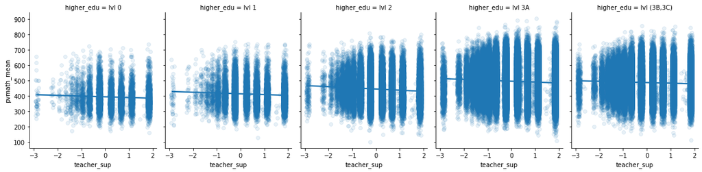

```python
multi_regplot_facet(teacher_sup,'higher_edu','teacher_sup',height=4,aspect=0.8)
```

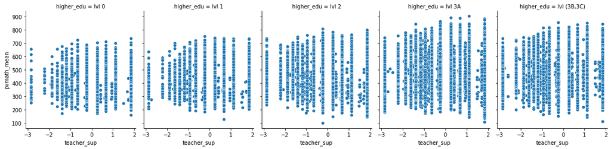

```python
multi_scatter_facet(teacher_sup,'higher_edu','teacher_sup',height=4,aspect=0.8)
```

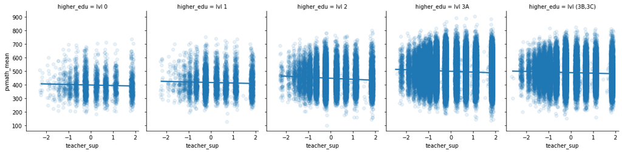

```python
no_outliers = remove_outlier(class_period,'teacher_sup')
multi_regplot_facet(no_outliers,'higher_edu','teacher_sup',height=4,aspect=0.8)
```

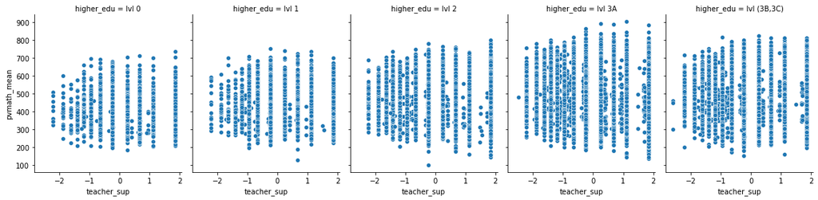

```python
multi_scatter_facet(no_outliers,'higher_edu','teacher_sup',height=4,aspect=0.8)
```

No clear trends with teacher support with level of education level

# Math_interest vs Higher_education vs PVMATH

```python
math_interest = analysis_df[~((analysis_df['math_interest'].isnull())|(analysis_df['higher_edu'].isnull()))].copy()
math_interest.shape
```

```
(278700, 12)
```

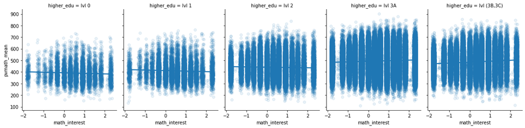

```python
multi_regplot_facet(math_interest,'higher_edu','math_interest',height=4,aspect=0.8)
```

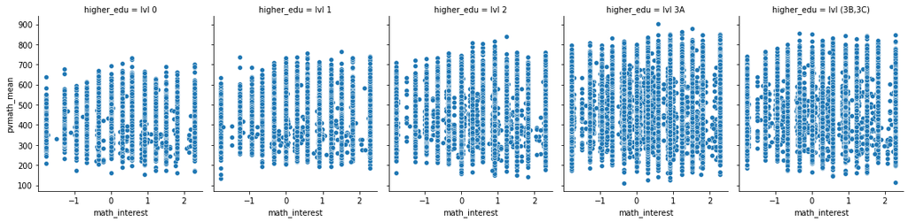

```python
multi_scatter_facet(math_interest,'higher_edu','math_interest',height=4,aspect=0.8)
```

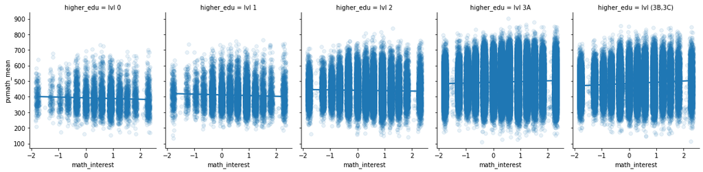

```python
no_outliers = remove_outlier(math_interest,'math_interest')
multi_regplot_facet(no_outliers,'higher_edu','math_interest',height=4,aspect=0.8)
```

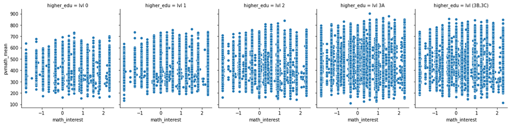

```python
multi_scatter_facet(no_outliers,'higher_edu','math_interest',height=4,aspect=0.8)
```

No clear trends with different math intreset of students with level of education of parents

# See how skipping days of school or being late affect PVMATH values

First we creat a dataframe that contain no null values for the columns of interest (skip_day,late)

```python
discipline_df = analysis_df[~((analysis_df['late'].isnull())|(analysis_df['skip_day'].isnull()))]
discipline_df.shape
```

```
(415270, 12)
```

```python
#create plotting data for interaction of late with skipping days with reference to PVMATH mean
discipline_mean = analysis_df.groupby(['late','skip_day'])['pvmath_mean'].mean()
discipline_mean = discipline_mean.reset_index(name='pvmath_mean')
discipline_mean = discipline_mean.pivot(index = 'late', columns = 'skip_day', values = 'pvmath_mean')
discipline_mean
```

| skip_day late | 5 or more | 3-4 Times | 1-2 Times | Never |
| --- | --- | --- | --- | --- |
| 5 or more | 398.542593 | 407.828651 | 428.208949 | 457.600855 |
| 3-4 Times | 399.977581 | 412.996123 | 435.615651 | 466.519357 |
| 1-2 Times | 409.669772 | 418.551617 | 439.465164 | 471.498162 |
| Never | 433.479904 | 444.237570 | 457.904492 | 495.430276 |

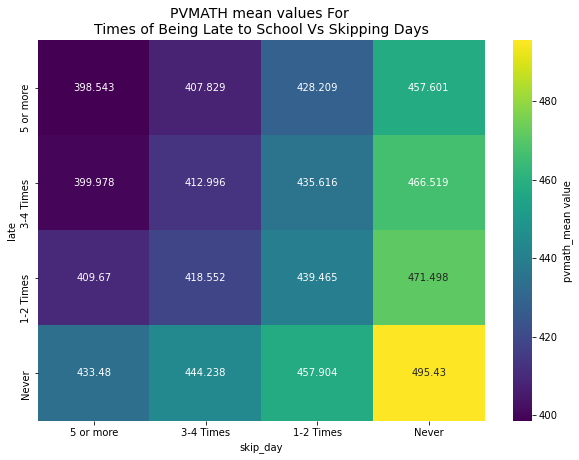

```python
#plotting heatmap
plt.figure(figsize=(10,7))
sns.heatmap(discipline_mean,annot=True,fmt='g',cbar_kws={'label':'pvmath_mean value'},cmap='viridis')
plt.title("PVMATH mean values For \nTimes of Being Late to School Vs Skipping Days",size=14)
plt.constrained_layout=True
```

**We can see that being late of skipping school days has an impact to the PVMATH mean value, where skipping days can be said to be more impactiful to PVMATH value than being late, Also how the PVMATH value decreases with being late of skipping days**

### Talk about some of the relationships you observed in this part of the investigation. Were there features that strengthened each other in terms of looking at your feature(s) of interest?

> **With more investigation about relation of late column with skip_day column and mean value for PVMATH the investigation strengthened the previous relation that late and skip day impact pvmath score and now we can see that both columns can also affect PVMATH value differently, and confirming that skipping school day has more impact on PVMATH value than just being late.**